# EPE Manuscript Analyses

Joey Heffner

02 September, 2021

# EPE Manuscript Analysis

The order of this Markdown will follow the order of results in the manuscript.

## Setup

To run this analysis script you’ll have to have the following packages installed (make sure `tidyverse` is updated):

| Packages1 | Packages2 | Packages3 | Packages4 |
| --- | --- | --- | --- |
| `here` | `tidyverse` | `knitr` | `kableExtra` |
| `lsr` | `lme4` | `lmerTest` | `broom.mixed` |
| `AICmodavg` | `cowplot` | `ggrepel` | `gridExtra` |
| `permutes` | `doParallel` | `purrr` | `sjPlot` |
| `ggstance` |  |  |  |

To install these packages simply use the `install.packages()` function and put each package name in as a character.

**Note**: If you’ve already used the `here()` function in another script, you will have to open a new instance of R to ensure the relative paths works for this script (or manually change the paths).

## Data

The general purpose of these experiments was to determine the relative contributions emotions and rewards have on decisions to punish. Experiments 1, 2, and 4 follow a similar design and have similar data structures, while Experiment 3 was a mouse-tracking study and has extremely large data files. Currently, loading Experiment 3 is turned off by default using a simple if statement (see setup code).

## Exclusion Criteria

`exclude` will specify whether participants correctly rated `neutral` on the circumplex. We tell participants in the instructions that “the center of the square represents a neutral, average, everyday feeling.”

We have preregistered a 100x100 pixel square around the center. If participants rate neutral within this square, they will not be excluded (`exclude = keep`) otherwise they will (`exclude = remove`).

# Experiment 1

## Fig. 1: Emotion Classification Task

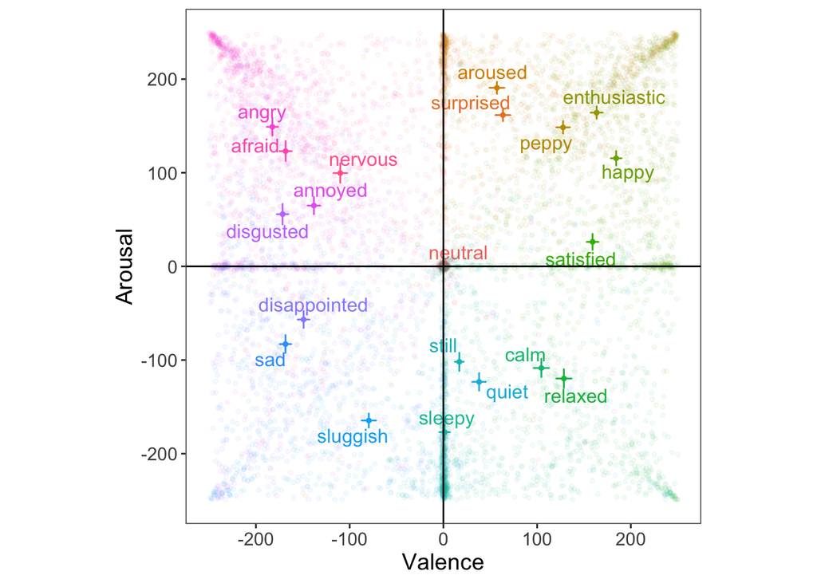

## Table 1: Experiment 1: Valence prediction errors predict decisions to punish better than reward prediction errors

Experiment 1: Valence prediction errors predict decisions to punish better than reward prediction errors

|  | Estimates |  |  |  |
| --- | --- | --- | --- | --- |
| Predictors | Log-Odds | SE | Z | p |
| Intercept | -2.56 | 0.18 | -14.26 | **<0.001** |
| Valence PE | -1.92 | 0.16 | -11.75 | **<0.001** |
| Arousal PE | 0.53 | 0.09 | 5.65 | **<0.001** |
| Reward PE | -1.10 | 0.14 | -7.62 | **<0.001** |
| N <sub>sub</sub> | 364 |  |  |  |
| Observations | 7280 |  |  |  |

```
## Data: table1_data
## Models:
## table1b: choice ~ RPE_scale + (1 + RPE_scale | sub)
## table1c: choice ~ RPE_scale + EPE_X1_scale + (1 + EPE_X1_scale + RPE_scale |
## table1c:     sub)
##         npar    AIC    BIC  logLik deviance  Chisq Df Pr(>Chisq)
## table1b    5 5505.4 5539.8 -2747.7   5495.4
## table1c    9 5000.7 5062.8 -2491.4   4982.7 512.65  4  < 2.2e-16 ***
## ---
## Signif. codes:  0 '***' 0.001 '**' 0.01 '*' 0.05 '.' 0.1 ' ' 1
```

```
## Data: table1_data
## Models:
## table1c: choice ~ RPE_scale + EPE_X1_scale + (1 + EPE_X1_scale + RPE_scale |
## table1c:     sub)
## table1: choice ~ EPE_X1_scale + EPE_Y1_scale + RPE_scale + (1 + EPE_X1_scale +
## table1:     EPE_Y1_scale + RPE_scale | sub)
##         npar    AIC    BIC  logLik deviance  Chisq Df Pr(>Chisq)
## table1c    9 5000.7 5062.8 -2491.4   4982.7
## table1    14 4940.5 5037.0 -2456.2   4912.5 70.239  5  9.139e-14 ***
## ---
## Signif. codes:  0 '***' 0.001 '**' 0.01 '*' 0.05 '.' 0.1 ' ' 1
```

```
##
## Repeated measures correlation
##
## r
## 0.8031948
##
## degrees of freedom
## 6915
##
## p-value
## 0
##
## 95% confidence interval
## 0.7946688 0.811404
```

```
## EPE_X1_scale EPE_Y1_scale    RPE_scale
##         1.55         1.04         1.54
```

## Subjective RPE analysis

Analysis contained in `epe_models.Rmd` in the oscar folder.

## Secondary model analysis

```
## Data: table1_data
## Models:
## table1: choice ~ EPE_X1_scale + EPE_Y1_scale + RPE_scale + (1 + EPE_X1_scale +
## table1:     EPE_Y1_scale + RPE_scale | sub)
## table1d: choice ~ RPE_scale * EPE_X1_scale * EPE_Y1_scale + (1 + EPE_X1_scale +
## table1d:     RPE_scale + EPE_Y1_scale | sub)
##         npar    AIC    BIC  logLik deviance  Chisq Df Pr(>Chisq)
## table1    14 4940.5 5037.0 -2456.2   4912.5
## table1d   18 4908.5 5032.6 -2436.2   4872.5 39.996  4  4.337e-08 ***
## ---
## Signif. codes:  0 '***' 0.001 '**' 0.01 '*' 0.05 '.' 0.1 ' ' 1
```

## Follow-up analyses (see Supplement analysis as well)

```
##
##  Maximum number of PQL iterations:  20
```

# Experiment 2 brief analysis (see Supplement)

# Figure 2

## Figure 2A

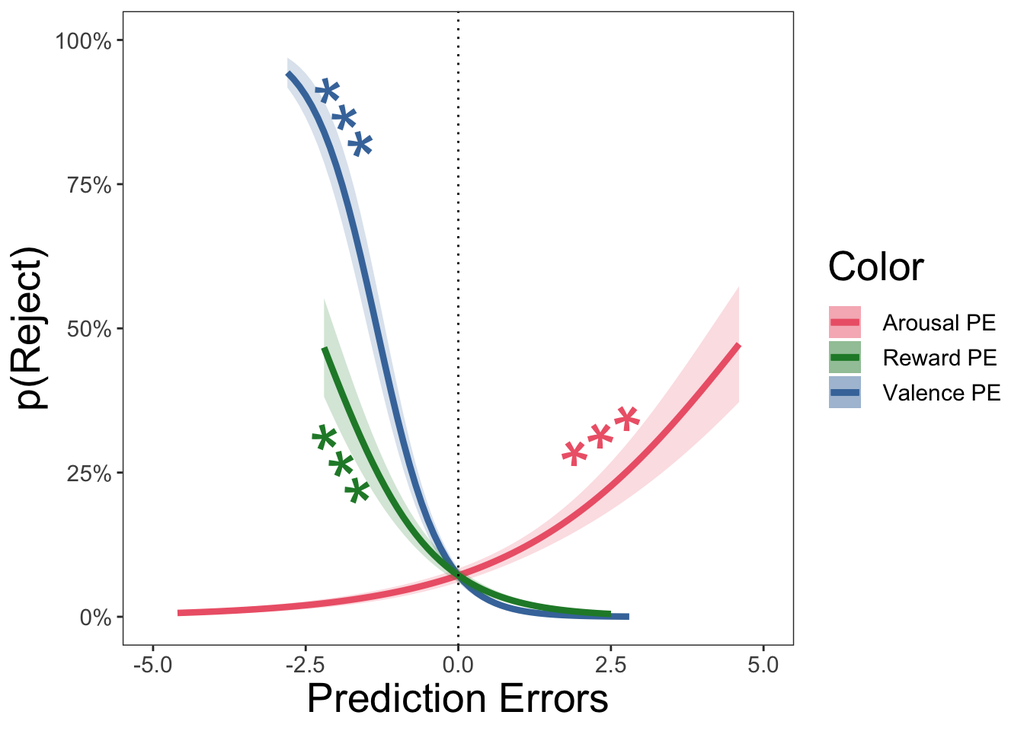

## Fig. 2B - Reverse vs Comp

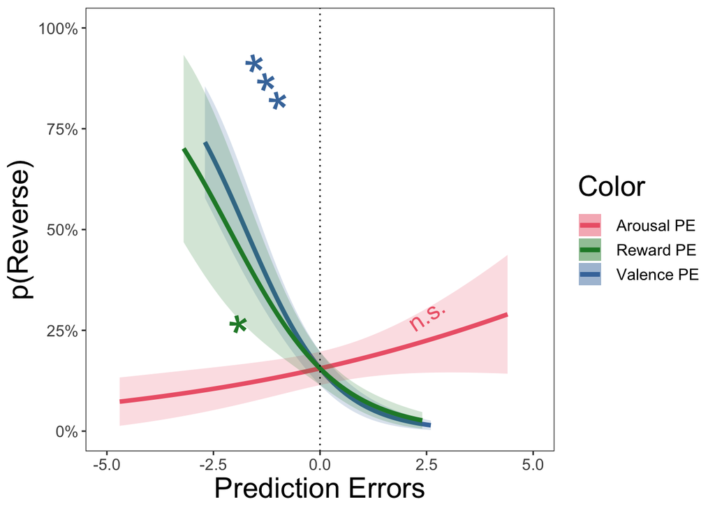

## Fig. 2C - Accept vs Punish

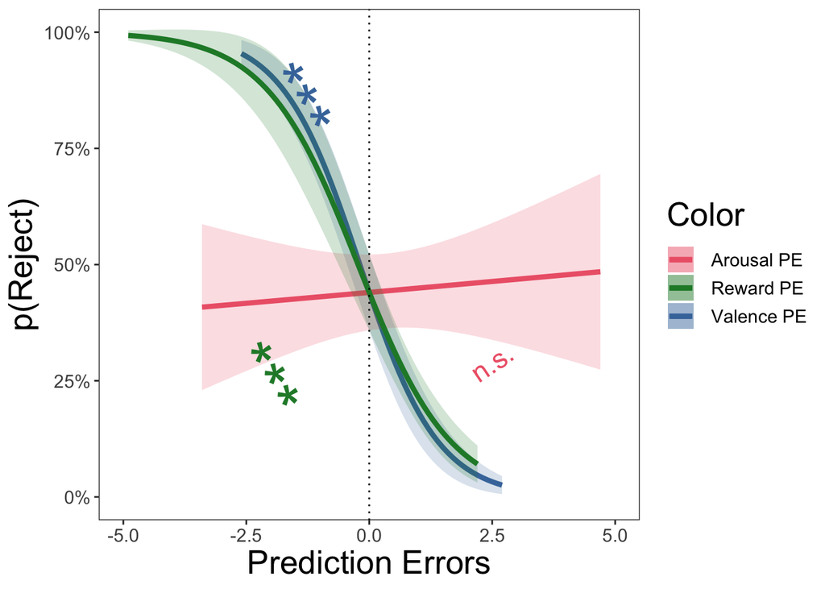

## Experiment 3 Subjective RPE Model (see `epe_model.Rmd` in oscar folder)

# Figure 3 (see Supplement for statistics and visualization)

# Table 2

Experiment 4: Individuals at risk of depression are less sensitive to unfairness

|  | Estimates |  |  |  |
| --- | --- | --- | --- | --- |
| Predictors | Log-Odds | SE | Z | p |
| Intercept | -4.57 | 0.48 | -9.56 | **<0.001** |
| Unfairness | 5.57 | 0.38 | 14.53 | **<0.001** |
| Depression | 1.42 | 0.60 | 2.38 | **0.018** |
| Unfairness:Depression | -1.80 | 0.42 | -4.24 | **<0.001** |
| N <sub>sub</sub> | 351 |  |  |  |
| Observations | 7020 |  |  |  |

# Experiment 4: Intext analyses

```
## Generalized linear mixed model fit by maximum likelihood (Laplace
##   Approximation) [glmerMod]
##  Family: binomial  ( logit )
## Formula:
## choice ~ EPE_X1_scale + EPE_Y1_scale + RPE_scale + (1 + EPE_X1_scale +
##     EPE_Y1_scale + RPE_scale | sub)
##    Data: e4_healthy
## Control: glmerControl(optimizer = "bobyqa", optCtrl = list(maxfun = 2e+05))
##
##      AIC      BIC   logLik deviance df.resid
##   2512.9   2601.3  -1242.4   2484.9     4086
##
## Scaled residuals:
##     Min      1Q  Median      3Q     Max
## -4.4207 -0.1953 -0.0649  0.0566  5.9187
##
## Random effects:
##  Groups Name         Variance Std.Dev. Corr
##  sub    (Intercept)  7.707    2.776
##         EPE_X1_scale 6.192    2.488    -0.44
##         EPE_Y1_scale 1.532    1.238    -0.38  0.09
##         RPE_scale    2.674    1.635     0.25 -0.74 -0.32
## Number of obs: 4100, groups:  sub, 205
##
## Fixed effects:
##              Estimate Std. Error z value Pr(>|z|)
## (Intercept)   -3.0017     0.2686 -11.174  < 2e-16 ***
## EPE_X1_scale  -2.0842     0.2914  -7.152 8.52e-13 ***
## EPE_Y1_scale   0.5704     0.1775   3.213  0.00131 **
## RPE_scale     -1.4122     0.2340  -6.035 1.59e-09 ***
## ---
## Signif. codes:  0 '***' 0.001 '**' 0.01 '*' 0.05 '.' 0.1 ' ' 1
##
## Correlation of Fixed Effects:
##             (Intr) EPE_X1 EPE_Y1
## EPE_X1_scal  0.013
## EPE_Y1_scal -0.285 -0.105
## RPE_scale    0.231 -0.597 -0.156
```

```
## Generalized linear mixed model fit by maximum likelihood (Laplace
##   Approximation) [glmerMod]
##  Family: binomial  ( logit )
## Formula:
## choice ~ EPE_X1_scale + EPE_Y1_scale + RPE_scale + (1 + EPE_X1_scale +
##     EPE_Y1_scale + RPE_scale | sub)
##    Data: e4_depress
## Control: glmerControl(optimizer = "bobyqa", optCtrl = list(maxfun = 2e+05))
##
##      AIC      BIC   logLik deviance df.resid
##   2272.8   2356.5  -1122.4   2244.8     2906
##
## Scaled residuals:
##     Min      1Q  Median      3Q     Max
## -6.1848 -0.3308 -0.1318  0.2205 11.4628
##
## Random effects:
##  Groups Name         Variance Std.Dev. Corr
##  sub    (Intercept)  4.0130   2.0033
##         EPE_X1_scale 0.4487   0.6699   -0.27
##         EPE_Y1_scale 0.4527   0.6728   -0.47 -0.61
##         RPE_scale    1.5101   1.2289   -0.02 -0.21 -0.19
## Number of obs: 2920, groups:  sub, 146
##
## Fixed effects:
##              Estimate Std. Error z value Pr(>|z|)
## (Intercept)  -2.21079    0.21374 -10.343  < 2e-16 ***
## EPE_X1_scale -0.94405    0.16262  -5.805 6.43e-09 ***
## EPE_Y1_scale  0.01143    0.13093   0.087     0.93
## RPE_scale    -1.42997    0.18348  -7.794 6.51e-15 ***
## ---
## Signif. codes:  0 '***' 0.001 '**' 0.01 '*' 0.05 '.' 0.1 ' ' 1
##
## Correlation of Fixed Effects:
##             (Intr) EPE_X1 EPE_Y1
## EPE_X1_scal  0.108
## EPE_Y1_scal -0.163 -0.224
## RPE_scale    0.188 -0.386 -0.135
```

# Table 3

Experiment 4: Individuals at risk of depression have selective impairment in emotion (but not reward) prediction errors

|  | Estimates |  |  |  |
| --- | --- | --- | --- | --- |
| Predictors | Log-Odds | SE | Z | p |
| Intercept | -2.73 | 0.22 | -12.58 | **<0.001** |
| Valence PE | -1.96 | 0.22 | -9.03 | **<0.001** |
| Depression | 0.31 | 0.30 | 1.04 | 0.296 |
| Arousal PE | 0.49 | 0.14 | 3.58 | **<0.001** |
| Reward PE | -1.27 | 0.19 | -6.54 | **<0.001** |
| Valence PE:Depression | 0.93 | 0.29 | 3.24 | **0.001** |
| Arousal PE:Depression | -0.47 | 0.18 | -2.54 | **0.011** |
| Reward PE:Depression | -0.22 | 0.25 | -0.88 | 0.378 |
| N <sub>sub</sub> | 351 |  |  |  |
| Observations | 7020 |  |  |  |

# Figure 4

## Figure 4a

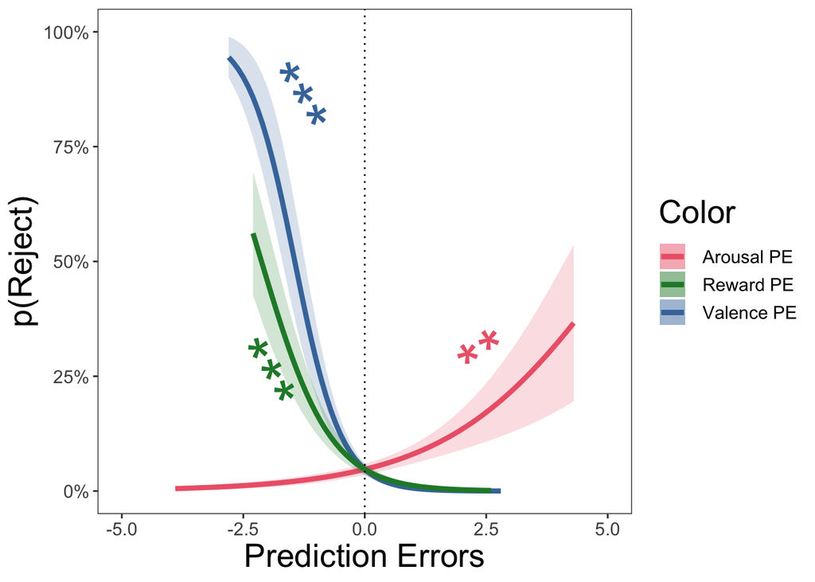

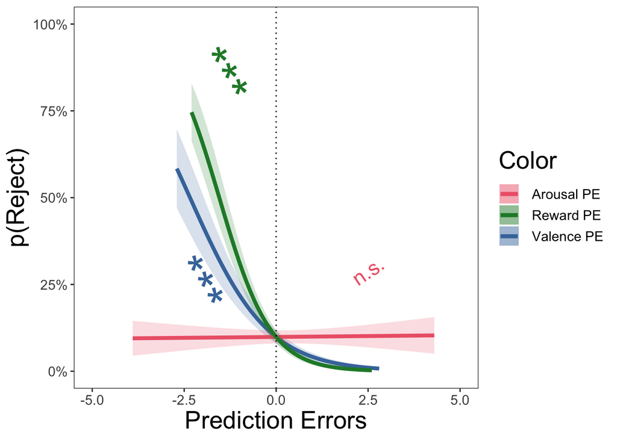

## Figure 4b

[figure not shown]

## Figure 4c

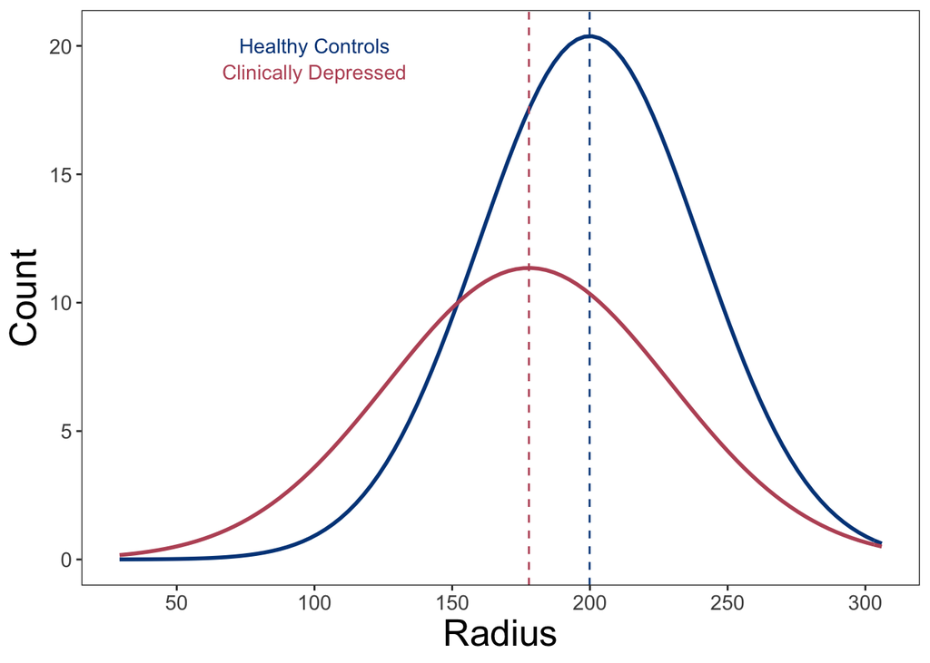

```
##
##  Welch Two Sample t-test
##
## data:  healthy_radius and clinical_radius
## t = 4.3286, df = 263.34, p-value = 2.133e-05
## alternative hypothesis: true difference in means is not equal to 0
## 95 percent confidence interval:
##  12.00510 32.04077
## sample estimates:
## mean of x mean of y
##  199.8797  177.8568
```

```
##
## Hedges's g
##
## g estimate: 0.4871515 (small)
## 95 percent confidence interval:
##     lower     upper
## 0.2715792 0.7027239
```

## Figure 4d

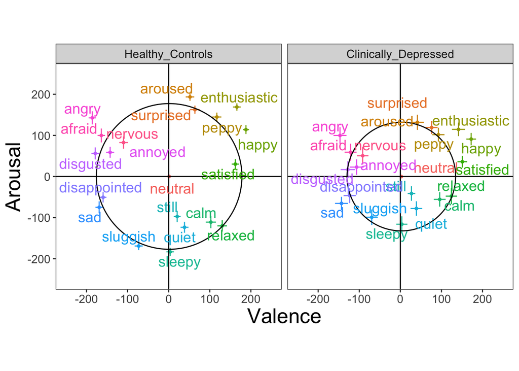